# Analysis of Experiment 3 data

Matt Jaquiery

21/06/2020

[Script run 2020-09-22 11:33:43]

# Introduction

How we judge our responsibility and the responsibility of others for actions’ outcomes has important consequences in our society. It is tightly related to whether we get rewarded or blamed for the actions we make, which is crucial for the maintenance of a cooperative and fair society. Even in our everyday lives, correctly or wrongfully attributing responsibility to ourselves and others for seemingly non crucial actions, can have emotional and long-term consequences.

How people attribute responsibility to themselves in a group is subjective: They tend to attribute higher responsibility for positive as compared to negative outcomes. This is known as the self-serving bias, where people claim more credit for positive events, while they duck responsibility for negative events (Caine & Schlenker, 1979; Forsyth & Schlenker, 1977; Leary & Forsyth, 1987; Miller & Schlenker, 1985). This bias however does not seem to be purely selfish: it also appears when people judge their group or another person’s responsibility (Palmeira et al., 2015; Taylor & Doria, 1981). For example, in the context of advising, people exhibit an ‘other-serving’ bias as they tend to credit more than blame an advisor (Palmeira et al., 2015).

In individual contexts, the rewards naturally seem to belong to the person producing a positive or negative outcome. In a group decision however, the outcome may be shared or given to one group member. It has been established that responsibility underlies ownership: control and intent of an action, which are directly associated with responsibility attributions, also predict whether a person is perceived as the owner of an object (Palamar et al., 2012). If attributions of responsibility predict ownership, is the opposite true? Here we would like to address 1) whether *Outcome ownership* changes attributions of responsibility and 2) whether *Outcome ownership* is necessary for the self-serving and/or other-serving bias to appear.  
We investigate this question in a group decision-making context, where only one member can receive the outcome in each round.

Participants will perform an online task where they make collective decisions through majority votes, then one member of the group can receive either a *Reward* or *No reward*. Finally they will rate the responsibility of the group members for the outcome. This paradigm will allow us to address both questions stated above:

1. by investigating whether responsibility attribution increases for the *Outcome owner*, although the control over the outcome is exactly similar.
2. By checking whether the self and other-serving bias of higher responsibility ratings for positive outcomes depend on *Outcome ownership*.

In other words, we will answer the question: do people exhibit the same self-serving bias when judging the responsibility for an outcome that is attributed to another member of their group? Do they also still exhibit an ‘other-serving’ bias when judging the responsibility of another group member who did not receive the outcome? We will also investigate (1b) whether self- and other-serving biases are of similar strength.

The study reported here is the third pilot study. In this study, participants provided a rating of responsibility for themself and the two other players after the outcome on every trial. For consistency with other studies in this series, we describe it as having a 2x2x2x2 factor structure, with all factors within-subjects:

- Whether the rated player is the *Outcome recipient*:
  - *Outcome owner* versus *Not outcome owner*
- The *Outcome valence*:
  - *Reward* versus *No reward*
- The *Vote status* of the participant in the group decision process:
  - *Participant in majority* versus *Participant in minority*
- Whether the *Responsibility judgement* is made about:
  - *Own responsibility* versus *Another’s responsibility*

# Method

## Statistical analysis

The primary analysis technique is ANOVA (Bayesian and frequentist). Bayesian ANOVA results are obtained by taking the likelihood of a model with the effect of interest plus all simpler effects compared to an alternative containing only the simpler effects. For main effects, this is the model for the effect alone compared to the intercept-only model; for one-way interactions this is the main effects plus interaction-of-interest model compared to the main effects only model.

## Materials

Experiments were custom-written in HTML/CSS/JavaScript using the [jsPsych framework](https://www.jspsych.org/) and undertaken by participants over the internet using their own devices. The experiment code was written by Marwa El Zein and Matt Jaquiery.

## Procedure

The entry point to the study is through recruitment on the Prolific (https://prolific.ac/) participant recruitment platform. Participants accepting the study are forwarded to the experiment website, where they provide informed consent for participation before entering the main experiment page. The experiment begins with detailed instruction pages which describe the structure of each round in the game, with screenshots of each stage, followed by a short training trial sequence. Once they have read the instructions and familiarised themselves with the game, participants begin the main experiment, which consists of 3 blocks of 20 trials. The 20 trials are a randomised sequence of balanced repetitions of each of the 8 unique trial types (as defined by whether the outcome is a reward/no reward; whether the participant is in the majority/minority; and whether the participant receives the outcome). The a reward/no reward trials and the trials with the participant in the majority/minority occurred equally frequently, while the participant received the outcome on 40% of all trials (because we wanted to maximise this variation but felt that 50% of trials might be noticeably unrealistic with four other players in the game).

Each trial begins with a display of the five players. This is followed by a screen in which the participant selects one of two gamble images. Gamble images are selected from a collection of hand-drawn images of gambling devices and paraphernalia, and are counterbalanced such that each pair of images is shown the same number of times. Which gamble is selected has no influence on the outcome of the trial, which is predetermined. Once the participant selects a gamble the other option vanishes.

If the participant has not selected a gamble by the end of the choice window, the rest of the trial is cancelled and the participant is shown a warning message which states that they have failed to make a choice in time. If the participant did select a gamble, the next screen indicates which gamble has been selected through the majority vote of all five players. Next, the gamble is allocated to one of the players and its outcome is shown (a coin for a rewarded trial or a coin with a cross through it for an unrewarded trial).

Once all 60 experimental trials have been completed, participants are debriefed, thanked, and returned to Prolific. Payment follows once all participants have completed the study and bonuses have been calculated.

## Open science

### Open materials

Materials for the studies can be found on the [GitHub repository](https://github.com/mjaquiery/responsibility-by-reward/tree/35474eada0141838972fc86006c61f104a02e835/ATTRRESP) as it stood on 18th June 2020.

### Open data

We are happy to share the experimental data for these pilot studies, but may not upload them to a repository unless requested. Data for the main experiments will available online.

[output not shown]

### Exclusions

(#tab:descriptive stats)

| Reason | N excluded |
| --- | --- |
| double_entry | 2.00 |
| missed_trials | 6.00 |
| trial_count | 2.00 |
| consec_resp | 2.00 |
| total_unique_exclusions | 12.00 |

### Demographics

```
## # A tibble: 2 x 1
##   unique_genders
##   <chr>
## 1 F
## 2 M
```

Participants self-reported a mean age of 26 (SD = 6.8) years and their genders as M (36), F (21), or otherwise (0).

Data were collected on the following days:

(#tab:experiment dates)

| Date | Participants |
| --- | --- |
| 2020-06-17 | 2 |
| 2020-06-18 | 55 |

### Response times

Participants make four responses on a trial, choosing a gamble and indicating how responsible each of the players was for the decision.

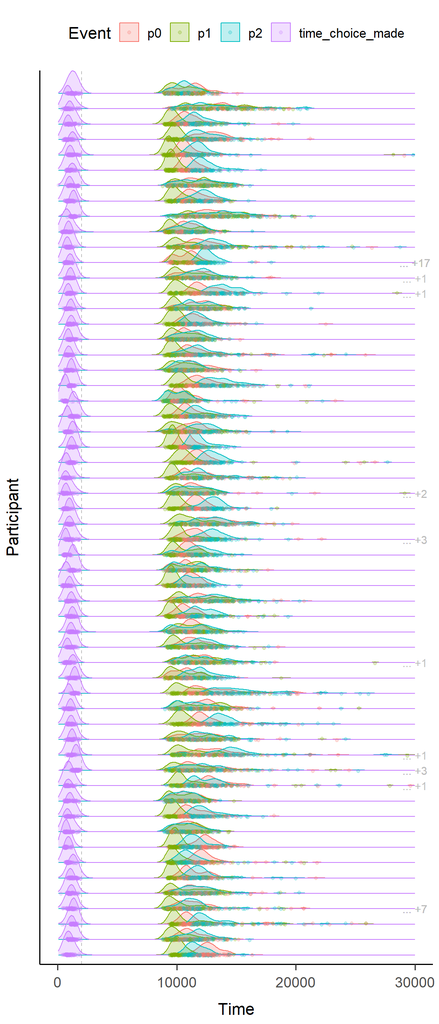

### Feeling of responsibility scale usage

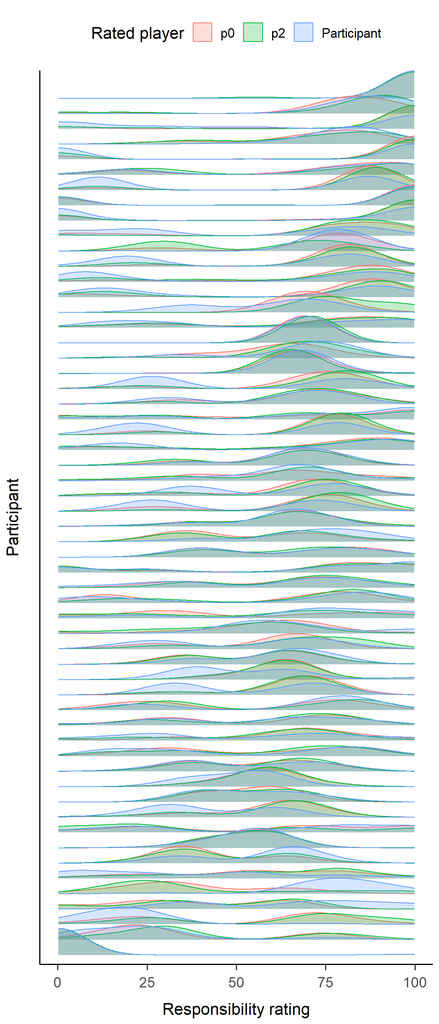

## Inferential statistics

Participants make one rating of responsibility for each of the three players (including themself) on each trial. These data are averaged in order to conduct ANOVA by organising each rating on each trial according to the following factors:

- ANOVA:
  - *Outcome valence*: Whether the trial result is *Reward* or *No reward*
  - *Outcome recipient*: Whether the rated player is the *Outcome owner* or *Not outcome owner*
  - *Is participant*: Whether the rated player is the *Participant* or *Another player*
  - *Vote status*: Whether the *Participant is in the majority* or *minority* in the gamble choice

### 1) Are players considered more responsible if they are the *Outcome owner*?

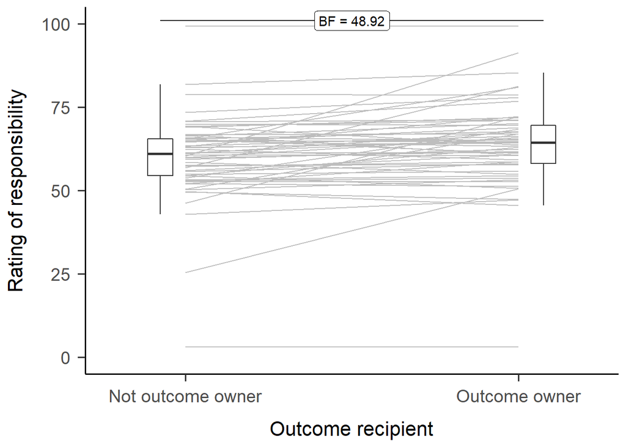

The figure shows participant mean responsibility ratings collapsed across other trial factors (lines) and their distributions (box plots). Participants rate players’ responsibility as higher when that player receives the outcome.

### 2) Does the other-serving bias, i.e, higher responsibility for positive *Outcome valence*, change if the rated player is *Not outcome owner*?

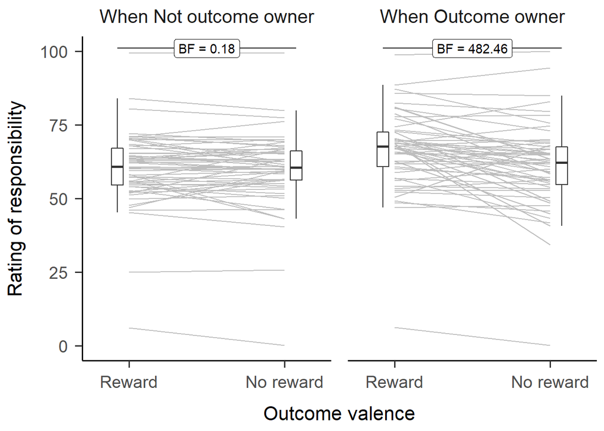

The figure shows participant mean responsibility ratings collapsed across other trial factors (lines) and their distributions (box plots). The ‘self/other-serving bias’ is evident on trials where the rated player gets the outcome than where another player gets the outcome.

We explored this statistically with a 2x2x2x2 ANOVA

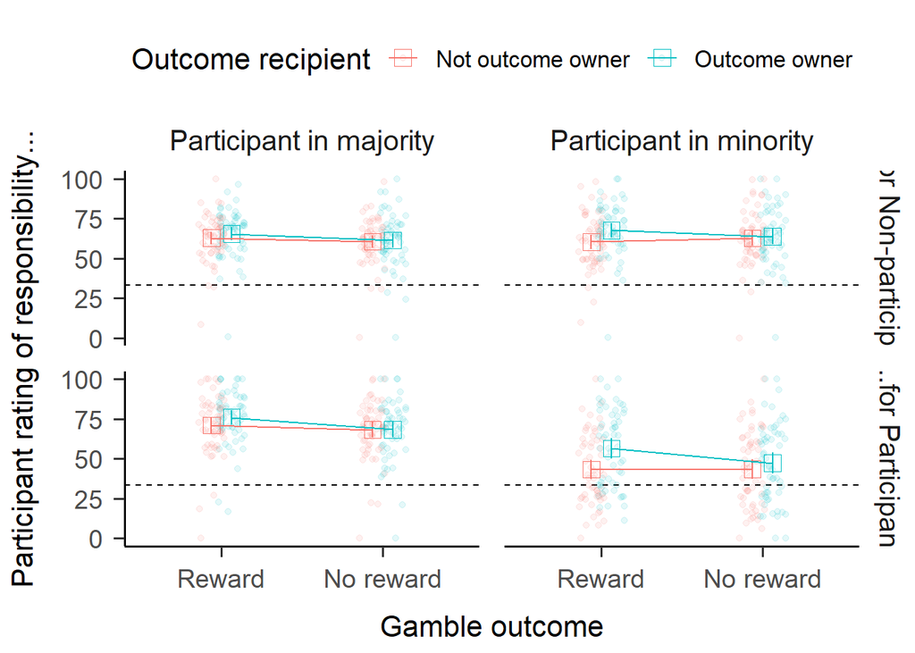

(#tab:unnamed-chunk-8)

|  | Effect | DFn | DFd | F | p | p<.05 | ges |
| --- | --- | --- | --- | --- | --- | --- | --- |
| ANOVA |  |  |  |  |  |  |  |
| 2 | outcome | 1.00 | 56.00 | 27.28 | 0.00 | * | 0.01 |
| 3 | rated_gets_outcome | 1.00 | 56.00 | 14.80 | 0.00 | * | 0.01 |
| 4 | status | 1.00 | 56.00 | 63.58 | 0.00 | * | 0.08 |
| 5 | is_participant | 1.00 | 56.00 | 3.90 | 0.05 |  | 0.01 |
| 6 | outcome:rated_gets_outcome | 1.00 | 56.00 | 13.62 | 0.00 | * | 0.01 |
| 7 | outcome:status | 1.00 | 56.00 | 2.51 | 0.12 |  | 0.00 |
| 8 | rated_gets_outcome:status | 1.00 | 56.00 | 9.71 | 0.00 | * | 0.00 |
| 9 | outcome:is_participant | 1.00 | 56.00 | 7.55 | 0.01 | * | 0.00 |
| 10 | rated_gets_outcome:is_participant | 1.00 | 56.00 | 7.09 | 0.01 | * | 0.00 |
| 11 | status:is_participant | 1.00 | 56.00 | 35.43 | 0.00 | * | 0.10 |
| 12 | outcome:rated_gets_outcome:status | 1.00 | 56.00 | 7.29 | 0.01 | * | 0.00 |
| 13 | outcome:rated_gets_outcome:is_participant | 1.00 | 56.00 | 4.96 | 0.03 | * | 0.00 |
| 14 | outcome:status:is_participant | 1.00 | 56.00 | 0.55 | 0.46 |  | 0.00 |
| 15 | rated_gets_outcome:status:is_participant | 1.00 | 56.00 | 3.95 | 0.05 |  | 0.00 |
| 16 | outcome:rated_gets_outcome:status:is_participant | 1.00 | 56.00 | 0.01 | 0.93 |  | 0.00 |

(#tab:unnamed-chunk-9)

| M1 | M2 | BF.M1.M2 |  |
| --- | --- | --- | --- |
| status + outcome + is_participant + rated_gets_outcome + subject_id | status + is_participant + rated_gets_outcome + subject_id | 414.14 | + |
| status + outcome + is_participant + rated_gets_outcome + subject_id | status + outcome + is_participant + subject_id | 107,727,193,638.40 | + |
| status + outcome + is_participant + rated_gets_outcome + subject_id | outcome + is_participant + rated_gets_outcome + subject_id | 4,793,683,858,398,939,005,806,004,088,668,862,444,000,462,420,206,406,068.00 | + |
| status + outcome + is_participant + rated_gets_outcome + subject_id | status + outcome + rated_gets_outcome + subject_id | 146,934,976,119,672.34 | + |
| status + outcome + is_participant + rated_gets_outcome + outcome:rated_gets_outcome + subject_id | status + outcome + is_participant + rated_gets_outcome + subject_id | 8,940.48 | + |
| status + outcome + status:outcome + is_participant + rated_gets_outcome + subject_id | status + outcome + is_participant + rated_gets_outcome + subject_id | 1.11 |  |
| status + outcome + is_participant + rated_gets_outcome + status:rated_gets_outcome + subject_id | status + outcome + is_participant + rated_gets_outcome + subject_id | 30.14 | + |
| status + outcome + is_participant + outcome:is_participant + rated_gets_outcome + subject_id | status + outcome + is_participant + rated_gets_outcome + subject_id | 0.41 |  |
| status + outcome + is_participant + rated_gets_outcome + is_participant:rated_gets_outcome + subject_id | status + outcome + is_participant + rated_gets_outcome + subject_id | 0.64 |  |
| status + outcome + is_participant + status:is_participant + rated_gets_outcome + subject_id | status + outcome + is_participant + rated_gets_outcome + subject_id | 5,064,014,130,678,290,215,086,288,440,022,666,446,684,206,446,488,228,466,846,064,444,668,822,220,002,682,884,246,204,084,608,200,460,486,488,480,884,082,468,880,008,226,020,406,686,246.00 | + |
| status + outcome + status:outcome + is_participant + status:is_participant + outcome:is_participant + rated_gets_outcome + status:rated_gets_outcome + outcome:rated_gets_outcome + status:outcome:rated… | status + outcome + status:outcome + is_participant + status:is_participant + outcome:is_participant + rated_gets_outcome + status:rated_gets_outcome + outcome:rated_gets_outcome + is_participant:rated… | 0.72 |  |
| status + outcome + status:outcome + is_participant + status:is_participant + outcome:is_participant + rated_gets_outcome + status:rated_gets_outcome + outcome:rated_gets_outcome + is_participant:rated… | status + outcome + status:outcome + is_participant + status:is_participant + outcome:is_participant + rated_gets_outcome + status:rated_gets_outcome + outcome:rated_gets_outcome + is_participant:rated… | 0.18 | - |
| status + outcome + status:outcome + is_participant + status:is_participant + outcome:is_participant + status:outcome:is_participant + rated_gets_outcome + status:rated_gets_outcome + outcome:rated_get… | status + outcome + status:outcome + is_participant + status:is_participant + outcome:is_participant + rated_gets_outcome + status:rated_gets_outcome + outcome:rated_gets_outcome + is_participant:rated… | 0.06 | - |
| status + outcome + status:outcome + is_participant + status:is_participant + outcome:is_participant + rated_gets_outcome + status:rated_gets_outcome + outcome:rated_gets_outcome + is_participant:rated… | status + outcome + status:outcome + is_participant + status:is_participant + outcome:is_participant + rated_gets_outcome + status:rated_gets_outcome + outcome:rated_gets_outcome + is_participant:rated… | 0.23 | - |
| status + outcome + status:outcome + is_participant + status:is_participant + outcome:is_participant + status:outcome:is_participant + rated_gets_outcome + status:rated_gets_outcome + outcome:rated_get… | status + outcome + status:outcome + is_participant + status:is_participant + outcome:is_participant + status:outcome:is_participant + rated_gets_outcome + status:rated_gets_outcome + outcome:rated_get… | 0.16 | - |

There are both areas of overlap and areas of disagreement between the Bayesian and frequentist ANOVAs. These approaches agree on the presence of main effects for *Outcome valence*, *Outcome recipient*, and *Vote status*, but while the Bayesian ANOVA shows evidence of an effect of whether the rated player *Is the participant*, this effect is non-significant.

For two-way interactions, the approaches agree on the presence of interactions between *Outcome valence* and *Outcome recipient*, between *Outcome recipient* and *Vote status*, and between *Vote status* and whether the rated player *Is the participant*. The Bayesian test was inconclusive for the *Outcome valence* and *Vote status* interaction, and the effect was non-signficant. The frequentist tests showed significant effects for the other two-way interactions (for *Outcome valence* and *Is participant* and for *Outcome recipient* and *Is participant*), but the Bayesian tests were inconclusive for both of these effects.

The three-way interaction between *Outcome valence*, *Outcome recipient*, and *Vote status* was significant, but inconclusive. The three-way interaction between *Outcome valence*, *Outcome recipient*, and *Is participant* was significant but the Bayesian test suggested evidence for a null effect. Neither the remaining three-way interactions nor the four-way interaction were significant, and all showed evidence for the null.

# Interpretation

Players are considered more responsible if they get the outcome than otherwise. The bias towards greater responsibility ratings for Reward as opposed to No reward outcomes appears to be largely confined to the player receiving the outcome. Whether the participant’s vote is for the decision which gets taken appears to matter more than whether the player rated is the participant or not, at least in terms of the way these factors interact with the valence and recipient of the reward.

# Credits

## R Packages

(#tab:R packages)

| Package | Citations |
| --- | --- |
| base | R Core Team (2020). R: A language and environment for statistical computing. R Foundation for Statistical Computing, Vienna, Austria. URL https://www.R-project.org/. |
| papaja | Aust, F. & Barth, M. (2020). papaja: Prepare reproducible APA journal articles with R Markdown. R package version 0.1.0.9997, retrieved from https://github.com/crsh/papaja |
| BayesFactor | Richard D. Morey and Jeffrey N. Rouder (2018). BayesFactor: Computation of Bayes Factors for Common Designs. R package version 0.9.12-4.2. https://CRAN.R-project.org/package=BayesFactor |
| Matrix | Douglas Bates and Martin Maechler (2019). Matrix: Sparse and Dense Matrix Classes and Methods. R package version 1.2-18. https://CRAN.R-project.org/package=Matrix |
| coda | Martyn Plummer, Nicky Best, Kate Cowles and Karen Vines (2006). CODA: Convergence Diagnosis and Output Analysis for MCMC, R News, vol 6, 7-11 |
| ez | Michael A. Lawrence (2016). ez: Easy Analysis and Visualization of Factorial Experiments. R package version 4.4-0. https://CRAN.R-project.org/package=ez |
| ggridges | Claus O. Wilke (2020). ggridges: Ridgeline Plots in ‘ggplot2’. R package version 0.5.2. https://CRAN.R-project.org/package=ggridges |
| forcats | Hadley Wickham (2020). forcats: Tools for Working with Categorical Variables (Factors). R package version 0.5.0. https://CRAN.R-project.org/package=forcats |
| stringr | Hadley Wickham (2019). stringr: Simple, Consistent Wrappers for Common String Operations. R package version 1.4.0. https://CRAN.R-project.org/package=stringr |
| dplyr | Hadley Wickham, Romain François, Lionel Henry and Kirill Müller (2020). dplyr: A Grammar of Data Manipulation. R package version 1.0.0. https://CRAN.R-project.org/package=dplyr |
| purrr | Lionel Henry and Hadley Wickham (2020). purrr: Functional Programming Tools. R package version 0.3.4. https://CRAN.R-project.org/package=purrr |
| readr | Hadley Wickham, Jim Hester and Romain Francois (2018). readr: Read Rectangular Text Data. R package version 1.3.1. https://CRAN.R-project.org/package=readr |
| tidyr | Hadley Wickham and Lionel Henry (2020). tidyr: Tidy Messy Data. R package version 1.1.0. https://CRAN.R-project.org/package=tidyr |
| tibble | Kirill Müller and Hadley Wickham (2020). tibble: Simple Data Frames. R package version 3.0.1. https://CRAN.R-project.org/package=tibble |
| ggplot2 | H. Wickham. ggplot2: Elegant Graphics for Data Analysis. Springer-Verlag New York, 2016. |
| tidyverse | Wickham et al., (2019). Welcome to the tidyverse. Journal of Open Source Software, 4(43), 1686, https://doi.org/10.21105/joss.01686 |

## Funding

Marwa El Zein is a Sir Henry Wellcome Postdoctoral Fellow at University College London, funded by The Wellcome Trust.

Matt Jaquiery is funded by a studentship from the [Medical Research Council](https://mrc.ukri.org/) (reference 1943590) and the University of Oxford [Department of Experimental Psychology](https://www.psy.ox.ac.uk/) (reference 17/18_MSD_661552).